# Stroke Analysis

## Data

For this work we used the dataset **Stroke Prediction Dataset** retrieved from [Kaggle](https://www.kaggle.com/fedesoriano/stroke-prediction-dataset).

We used the dataset to predict whether a patient is likely to get stroke based on the input parameters like gender, age, various diseases, and smoking status. Each row in the data provides relavant information about the patient.

Below the information about the attributes:

1. id: unique identifier
2. gender: “Male”, “Female” or “Other”
3. age: age of the patient
4. hypertension: 0 if the patient doesn’t have hypertension, 1 if the patient has hypertension
5. heart_disease: 0 if the patient doesn’t have any heart diseases, 1 if the patient has a heart disease
6. ever_married: “No” or “Yes”
7. work_type: “children”, “Govt_jov”, “Never_worked”, “Private” or “Self-employed”
8. Residence_type: “Rural” or “Urban”
9. avg_glucose_level: average glucose level in blood
10. bmi: body mass index
11. smoking_status: “formerly smoked”, “never smoked”, “smokes” or “Unknown”*
12. stroke: 1 if the patient had a stroke or 0 if not

*Note: “Unknown” in smoking_status means that the information is unavailable for this patient

```r
library(tidyverse)
library(Hmisc)
library(DMwR2)
library(gmodels)
library(GoodmanKruskal)
library(corrplot)
library(pscl)
library(caret)
library(pROC)
library(readr)

set.seed(42)
```

## Load the dataset

Set the current directory as working directory.

Load the dataset and convert the character in factor.

```r
#setwd(dirname(rstudioapi::getSourceEditorContext()$path))

stroke <- read_csv("stroke.csv", col_types = cols(hypertension = col_factor(levels = c("0","1")),
                                                  heart_disease = col_factor(levels = c("0","1")),
                                                  ever_married = col_factor(levels = c("Yes","No")),
                                                  bmi = col_double(),
                                                  stroke = col_factor(levels = c("0", "1")),
                                                  Residence_type = col_factor(levels = c("Urban","Rural"))))

head(stroke)
```

```
## # A tibble: 6 x 12
##      id gender   age hypertension heart_disease ever_married work_type
##   <dbl> <chr>  <dbl> <fct>        <fct>         <fct>        <chr>
## 1  9046 Male      67 0            1             Yes          Private
## 2 51676 Female    61 0            0             Yes          Self-employed
## 3 31112 Male      80 0            1             Yes          Private
## 4 60182 Female    49 0            0             Yes          Private
## 5  1665 Female    79 1            0             Yes          Self-employed
## 6 56669 Male      81 0            0             Yes          Private
## # ... with 5 more variables: Residence_type <fct>, avg_glucose_level <dbl>,
## #   bmi <dbl>, smoking_status <chr>, stroke <fct>
```

## Data Manipulation

```r
stroke$id <- NULL
stroke$smoking_status <- as.factor(stroke$smoking_status)

stroke <- stroke[stroke$gender == "Male" | stroke$gender == "Female",]
stroke$gender <- as.factor(stroke$gender)

stroke <- stroke[!stroke$work_type == "Never_worked",]
stroke$work_type <- as.factor(stroke$work_type)
```

## Data Visualization

First some boxplot to visualize stroke in association with some parameters.

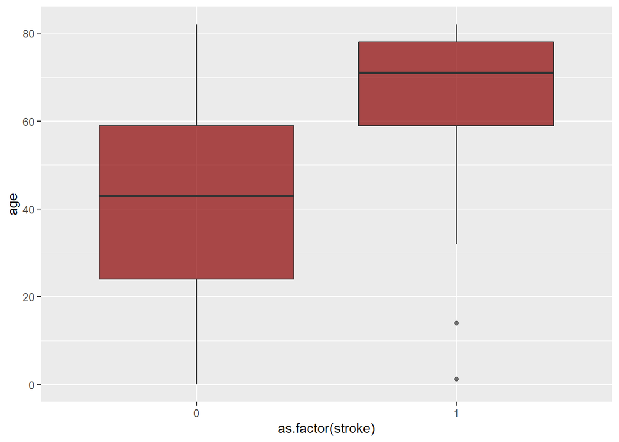

```r
ggplot(stroke, aes(x=as.factor(stroke),y=age))+
  geom_boxplot(fill= "darkred", alpha= 0.7)
```

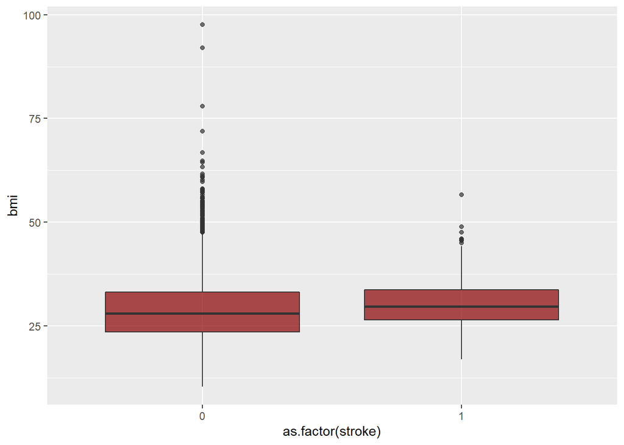

```r
ggplot(stroke, aes(x=as.factor(stroke),y=bmi))+
  geom_boxplot(fill= "darkred", alpha= 0.7)
```

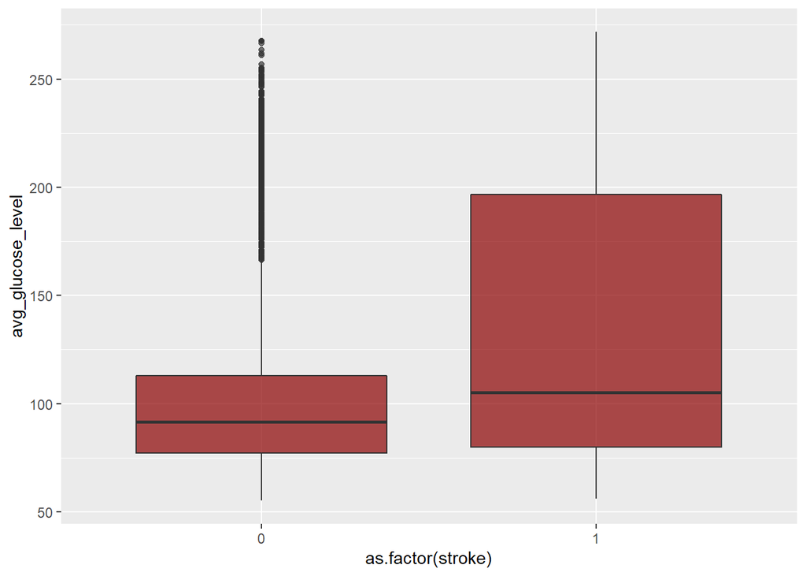

```r
ggplot(stroke, aes(x=as.factor(stroke),y=avg_glucose_level))+
  geom_boxplot(fill= "darkred", alpha= 0.7)
```

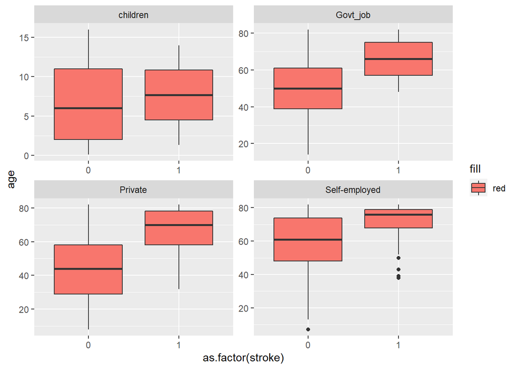

```r
ggplot(stroke, aes(x=as.factor(stroke), y=age, fill="red")) +
  geom_boxplot() +
  facet_wrap(~work_type, scale="free")
```

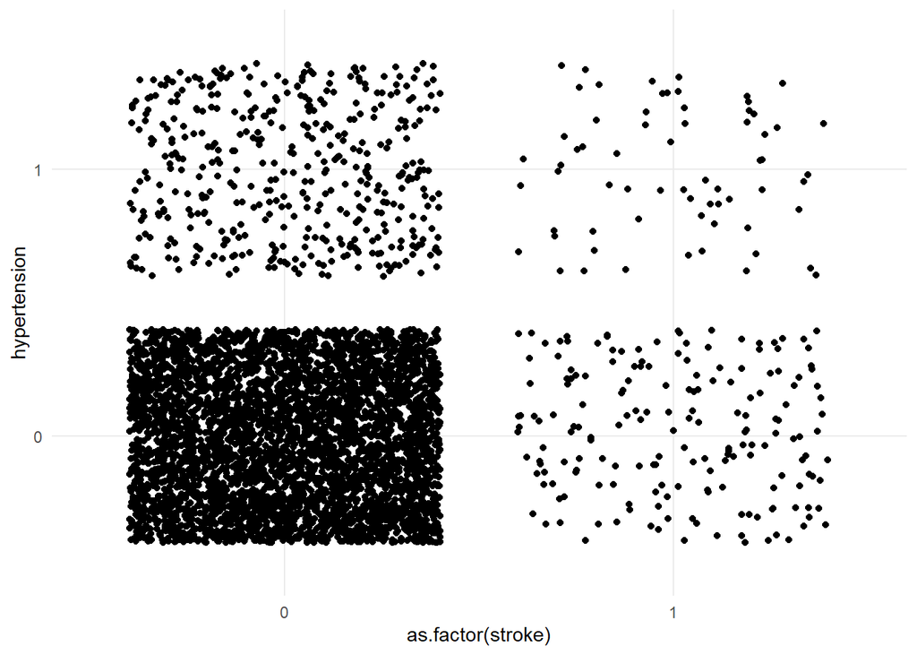

```r
ggplot(stroke, aes(x=as.factor(stroke),y=hypertension))+
  geom_jitter()+
  theme_minimal()
```

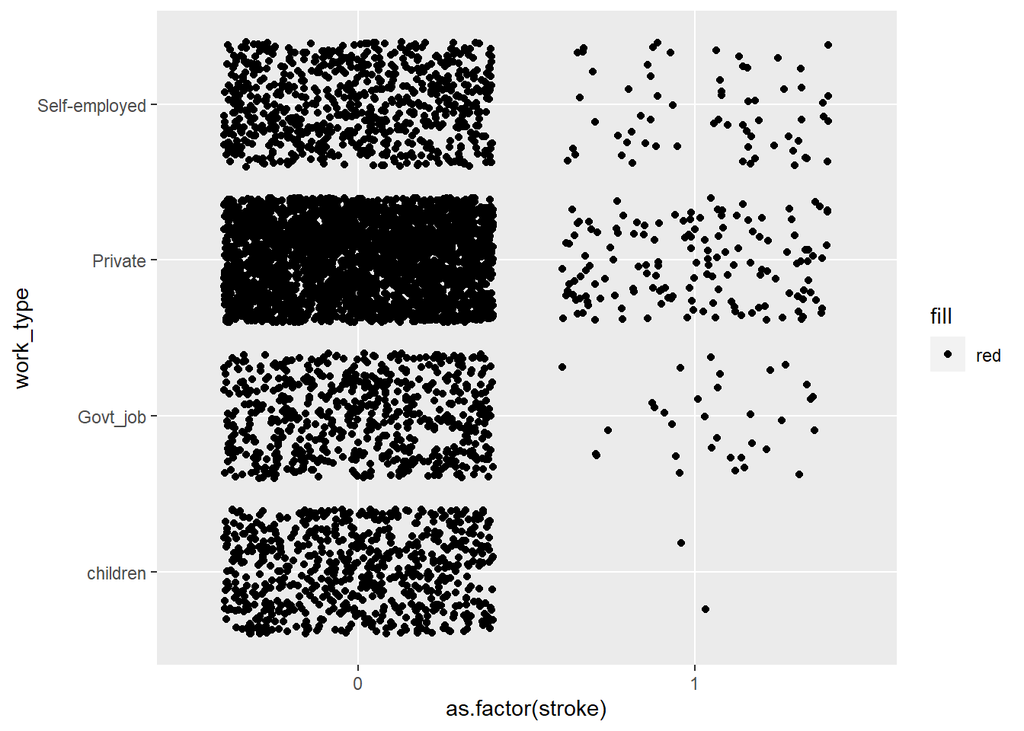

```r
ggplot(stroke, aes(x=as.factor(stroke), y=work_type, fill="red")) +
  geom_jitter()
```

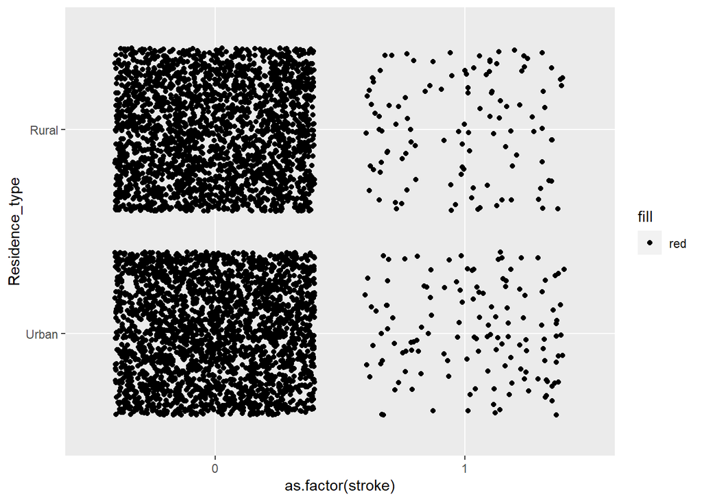

```r
ggplot(stroke, aes(x=as.factor(stroke), y=Residence_type, fill="red")) +
  geom_jitter()
```

## Dealing with NA

```r
stroke <- as_tibble(stroke)
sum(is.na(stroke$bmi))
```

```
## [1] 201
```

This is the number of NA in the column **bmi**, that we substituted makng a prediction.

```r
missing_index <- which(is.na(stroke$bmi))
X <- stroke[missing_index,]
train_v <- stroke[-c(missing_index),]

tree = caret::train(bmi ~ .,
                    data=train_v,
                    method="rpart",
                    trControl = trainControl(method = "cv"))

bmi_pred <- predict(tree, newdata = X)

stroke[missing_index,"bmi"] <- bmi_pred
sum(is.na(stroke$bmi))
```

```
## [1] 0
```

```r
sum(is.na(stroke))
```

```
## [1] 0
```